# Colombia COVID-19 - Central region

3/07/2020

## Our project

We decided to do **central Colombia**, basically because it is where the capital is.

We built a model for the number of `confirmed` cases using all the others covariates (plus some we created) and we estimated the predictive accuracy of our selected model.

## Description of variables

**ID de caso**: ID of the confirmed case.

**Fecha de diagnóstico**: Date in which the disease was diagnosed.

**Ciudad de ubicación**: City where the case was diagnosed.

**Departamento o Distrito**: Department or distric where the city belongs to.

**Atención**: Situation of the pacient: recovered, at home, at the hospital, at the ICU or deceased.

**Edad**: Age of the confirmed case.

**Sexo**: Sex of the confirmed cade.

**Tipo**: How the person got infected: in Colombia, abroad or unknown.

**País de procedencia**: Country of origin if the person got infected abroad.

## Preprocessing

We had to clean the dataset:

- We transformed the `Fecha de diagnóstico` variable into a `Date` variable,
- we fixed the variable `Id de caso` (some rows were missing so the numbers weren’t consecutive),
- we created a variable `Grupo de edad`,
- we transformed the variables `Grupo de edad`, `Departamento o Distrito`, `Ciudad de ubicación`, `Sexo`, `Atención`, `Tipo` into factors,
- we cleaned the column `País de procedencia` and created the variable `Continente de procedencia`.

```
##   ID de caso Fecha de diagnóstico Ciudad de ubicación Departamento o Distrito
## 1          1           2020-03-06              Bogotá             Bogotá D.C.
## 2          2           2020-03-09                Buga         Valle del Cauca
## 3          3           2020-03-09            Medellín               Antioquia
## 4          4           2020-03-11            Medellín               Antioquia
## 5          5           2020-03-11            Medellín               Antioquia
## 6          6           2020-03-11              Itagüí               Antioquia
##     Atención Edad Sexo        Tipo País de procedencia Grupo de edad
## 1 Recuperado   19    F   Importado              Italia         19_30
## 2 Recuperado   34    M   Importado              España         31_45
## 3 Recuperado   50    F   Importado              España         46_60
## 4 Recuperado   55    M Relacionado            Colombia         46_60
## 5 Recuperado   25    M Relacionado            Colombia         19_30
## 6       Casa   27    F Relacionado            Colombia         19_30
##   Continente de procedencia
## 1                    Europa
## 2                    Europa
## 3                    Europa
## 4                  Colombia
## 5                  Colombia
## 6                  Colombia
```

## New datasets

## New datasets part2

## Exploring the dataset

Number of cases confirmed day by day

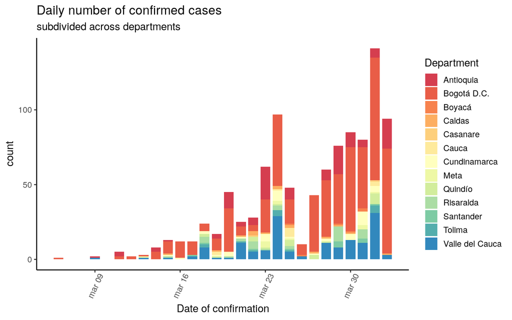

## Other plots

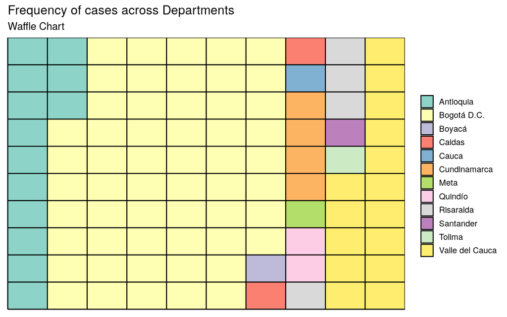

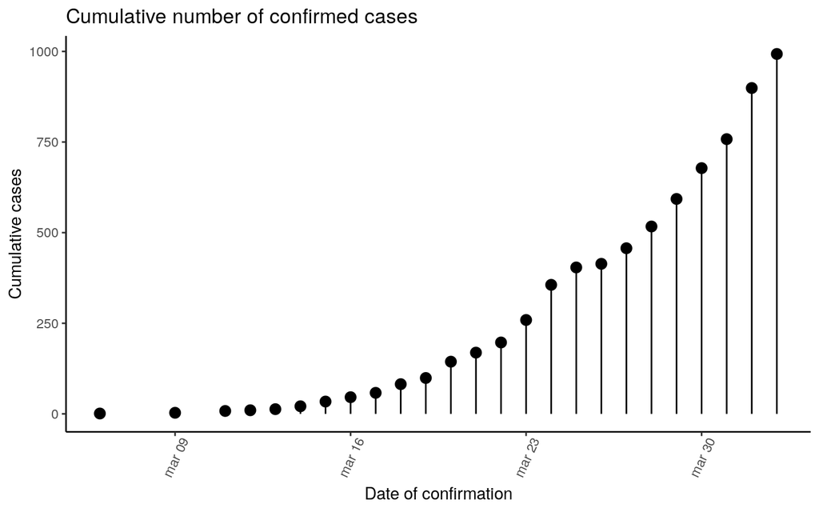

Here the growth seems exponential (and this is consistent with the fact that we are studying the early stages of the outbreak).

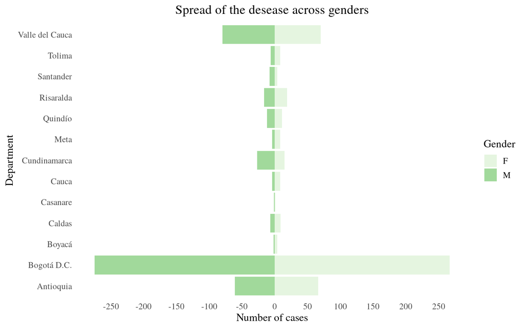

```r
brks <- seq(-250, 250, 50)
lbls <- as.character(c(seq(-250, 0, 50), seq(50, 250, 50)))

ggplot(data=colombia_covid, aes(x=`Departamento o Distrito`, fill = Sexo)) +
                              geom_bar(data = subset(colombia_covid, Sexo == "F")) +
                              geom_bar(data = subset(colombia_covid, Sexo == "M"), aes(y=..count..*(-1))) +
                              scale_y_continuous(breaks = brks,
                                               labels = lbls) +
                              coord_flip() +
                              labs(title="Spread of the desease across genders",
                                   y = "Number of cases",
                                   x = "Department",
                                   fill = "Gender") +
                              theme_tufte() +
                              theme(plot.title = element_text(hjust = .5),
                                    axis.ticks = element_blank()) +
                              scale_fill_brewer(palette = "Dark3")
```

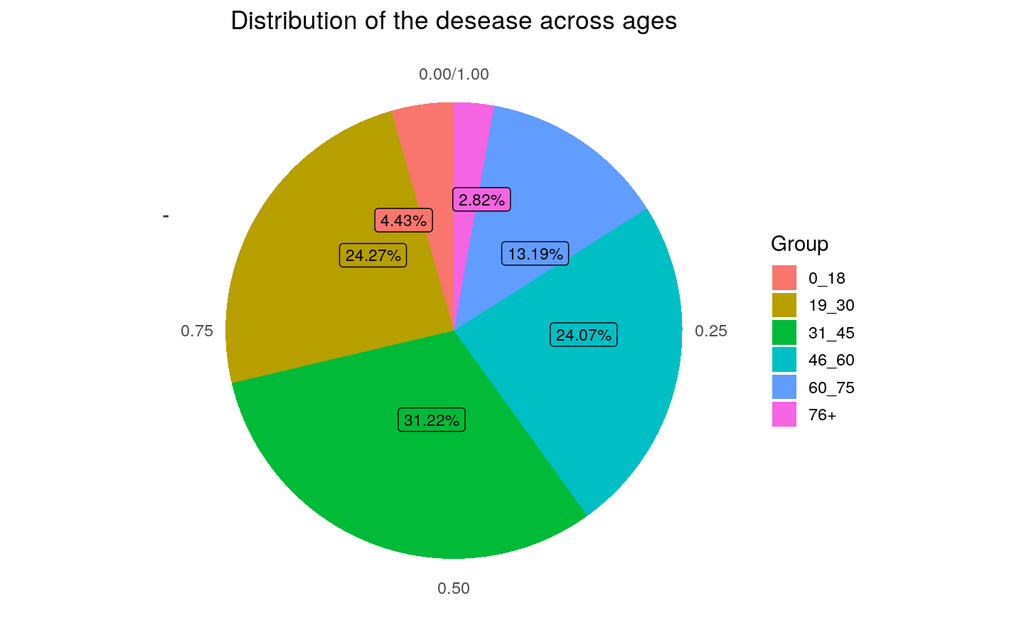

```r
#compute percentage so that we can label more precisely the pie chart
age_groups_pie <- colombia_covid %>%
  group_by(`Grupo de edad`) %>%
  count() %>%
  ungroup() %>%
  mutate(per=`n`/sum(`n`)) %>%
  arrange(desc(`Grupo de edad`))
age_groups_pie$label <- scales::percent(age_groups_pie$per)

age_pie <- ggplot(age_groups_pie, aes(x = "", y = per, fill = factor(`Grupo de edad`))) +
  geom_bar(stat="identity", width = 1) +
  theme(axis.line = element_blank(),
        plot.title = element_text(hjust=0.5)) +
  labs(fill="Age groups",
       x=NULL,
       y=NULL,
       title="Distribution of the desease across ages") +
  coord_polar(theta = "y") +
  #geom_text(aes(x=1, y = cumsum(per) - per/2, label=label))
  geom_label_repel(aes(x=1, y=cumsum(per) - per/2, label=label), size=3, show.legend = F, nudge_x = 0) +
  guides(fill = guide_legend(title = "Group"))

age_pie
```

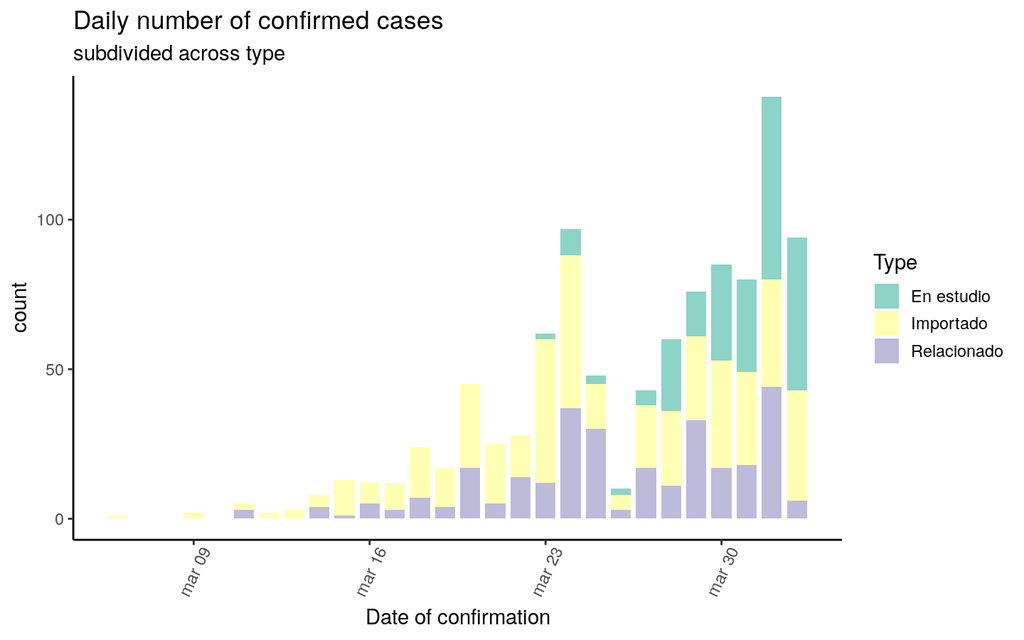

```r
theme_set(theme_classic())

ggplot(colombia_covid, aes(x = `Fecha de diagnóstico`)) +
  scale_fill_brewer(palette = "Set3") +
  geom_histogram(aes(fill=Tipo), width = 0.8, stat="count") +
  theme(axis.text.x = element_text(angle=65, vjust=0.6)) +
  labs(title = "Daily number of confirmed cases",
       subtitle = "subdivided across type",
       x = "Date of confirmation",
       fill = "Type")
```

## Tipo

I think that `en estudio` means that it is not clear while the case is imported or not, however it seems like there are more imported cases, we can count them:

```r
type_pie <- colombia_covid %>%
  group_by(Tipo) %>%
  count() %>%
  ungroup() %>%
  mutate(per=`n`/sum(`n`)) %>%
  arrange(desc(Tipo))
type_pie$label <- scales::percent(type_pie$per)
type_pie<-type_pie[names(type_pie)!="per"]
colnames(type_pie)<-c("Tipo", "Total number", "Percentage")
type_pie
```

```
## # A tibble: 3 x 3
##   Tipo        `Total number` Percentage
##   <fct>                <int> <chr>
## 1 Relacionado            291 29.3%
## 2 Importado              467 47.0%
## 3 En estudio             235 23.7%
```

## The frequentist approach

## Poisson with `Elapsed time` as predictor

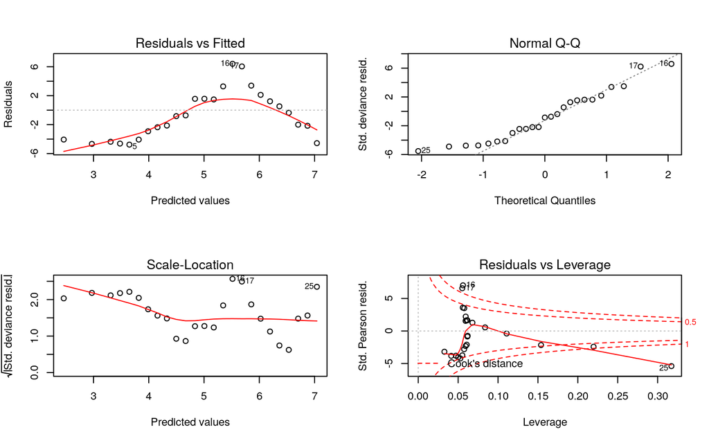

```
## [1] "Estimated overdispersion 11.0591714112992"
```

```
## [1] "AIC: 446.827929331767"
```

```
## [1] "Null deviance:  7859.81"   "Residual deviance: 280.62"
```

## Angela’s attempt

```
##
## Call:
## glm(formula = `Cumulative cases/Department` ~ `Elapsed time`,
##     family = poisson, data = cases_relev_dep)
##
## Deviance Residuals:
##      Min        1Q    Median        3Q       Max
## -13.9994   -4.7902   -2.1236    0.8586   16.3553
##
## Coefficients:
##                Estimate Std. Error z value Pr(>|z|)
## (Intercept)    0.982659   0.062709   15.67   <2e-16 ***
## `Elapsed time` 0.167306   0.002779   60.20   <2e-16 ***
## ---
## Signif. codes:  0 '***' 0.001 '**' 0.01 '*' 0.05 '.' 0.1 ' ' 1
##
## (Dispersion parameter for poisson family taken to be 1)
##
##     Null deviance: 8732.6  on 82  degrees of freedom
## Residual deviance: 3855.1  on 81  degrees of freedom
## AIC: 4285.4
##
## Number of Fisher Scoring iterations: 5
```

## New

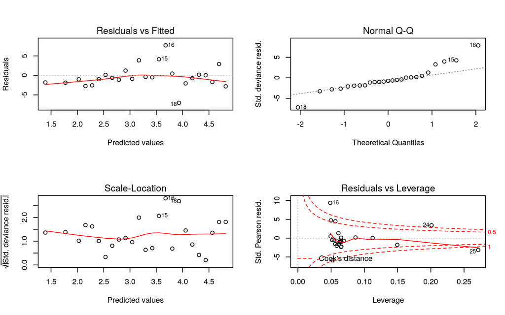

```
## [1] "AIC: 317.731647373115"
```

```
## [1] "Null deviance:  870.39"    "Residual deviance: 191.78"
```

### Poisson with time plus gender

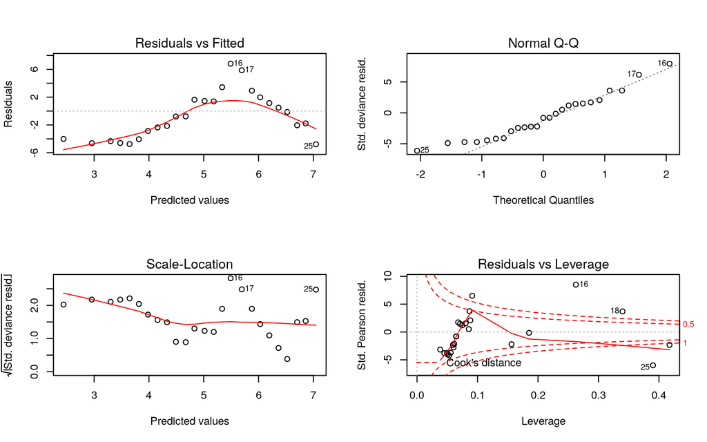

```r
poisson2 <- glm(`Cumulative cases` ~ `Elapsed time` + Sexo_M, data=data1, family=poisson)
par(mfrow=c(2,2))
plot(poisson2)
```

```r
paste("AIC:", poisson2$aic)
```

```
## [1] "AIC: 448.106201285854"
```

```r
paste(c("Null deviance: ", "Residual deviance:"),
       round(c(poisson2$null.deviance, deviance(poisson2)), 2))
```

```
## [1] "Null deviance:  7859.81"  "Residual deviance: 279.9"
```

### Poisson with `Elapsed time` plus `Group de edad`

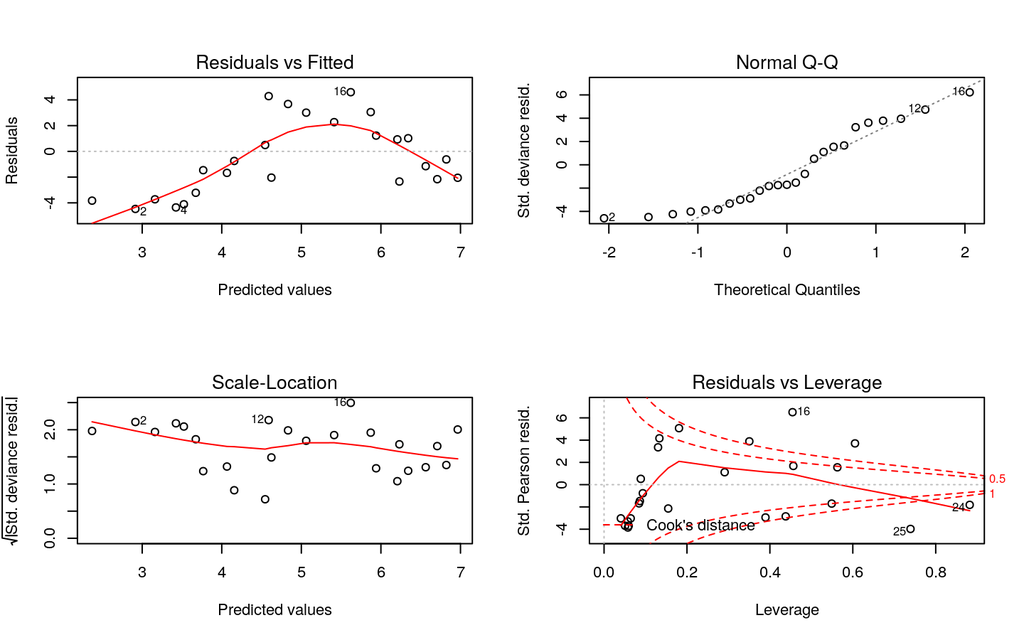

```r
poisson3 <- glm(`Cumulative cases` ~ `Elapsed time` + `Grupo de edad_19_30` + `Grupo de edad_31_45` + `Grupo de edad_46_60` + `Grupo de edad_60_75` + `Grupo de edad_76+`, data=data1, family=poisson)
par(mfrow=c(2,2))
plot(poisson3)
```

```r
pred.pois3 <- poisson3$fitted.values
res.st3 <- (data1$`Cumulative cases` - pred.pois3)/sqrt(pred.pois3)
#n=25
#k=7
#n-k=18
print(paste("Estimated overdispersion", est.overdispersion <- sum(res.st3^2)/18))
```

```
## [1] "Estimated overdispersion 10.001532070592"
```

```r
paste("AIC:", poisson3$aic)
```

```
## [1] "AIC: 376.950305422531"
```

```r
paste(c("Null deviance: ", "Residual deviance:"),
       round(c(poisson3$null.deviance, deviance(poisson3)), 2))
```

```
## [1] "Null deviance:  7859.81"   "Residual deviance: 200.75"
```

## Poisson with `Elapsed time`, `Age` and ’Departments` as predictors

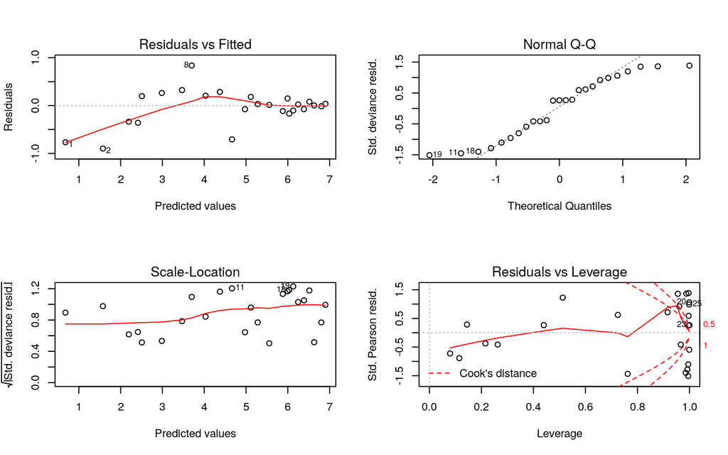

```r
#Running poisson with the variable representing time, age and departments as predictors
poisson4 <- glm(`Cumulative cases` ~ `Elapsed time` + `Grupo de edad_19_30` + `Grupo de edad_31_45` + `Grupo de edad_46_60` + `Grupo de edad_60_75` + `Grupo de edad_76+` + `Departamento o Distrito_Bogotá D.C.` + `Departamento o Distrito_Boyacá` + `Departamento o Distrito_Caldas` + `Departamento o Distrito_Casanare` + `Departamento o Distrito_Cauca` + `Departamento o Distrito_Cundinamarca` + `Departamento o Distrito_Meta` + `Departamento o Distrito_Quindío` + `Departamento o Distrito_Risaralda` + `Departamento o Distrito_Santander` + `Departamento o Distrito_Tolima` + `Departamento o Distrito_Valle del Cauca`, data=data1, family=poisson)
par(mfrow=c(2,2))
plot(poisson4)
```

```r
pred.pois4 <- poisson4$fitted.values
res.st4 <- (data1$`Cumulative cases` - pred.pois4)/sqrt(pred.pois4)
#n=25
#k=19
#n-k=6
print(paste("Estimated overdispersion", est.overdispersion <- sum(res.st4^2)/6))
```

```
## [1] "Estimated overdispersion 0.516840130836562"
```

```r
paste("AIC:", poisson4$aic)
```

```
## [1] "AIC: 203.506208494973"
```

```r
paste(c("Null deviance: ", "Residual deviance:"),
       round(c(poisson4$null.deviance, deviance(poisson4)), 2))
```

```
## [1] "Null deviance:  7859.81" "Residual deviance: 3.3"
```

## Poisson with `Elapsed time`, `Age`, `Departments` and `Continent of origin` as predictors

```r
#poisson5 <- glm(`Cumulative cases` ~ `Elapsed time` + `Grupo de edad_19_30` + `Grupo de edad_31_45` + `Grupo de edad_46_60` + `Grupo de edad_60_75` + `Grupo de edad_76+` + `Departamento o Distrito_Bogotá D.C.`+`Departamento o Distrito_Boyacá`+`Departamento o Distrito_Caldas` + `Departamento o Distrito_Casanare`+`Departamento o Distrito_Cauca`+`Departamento o Distrito_Cundinamarca`+`Departamento o Distrito_Meta`+`Departamento o Distrito_Quindío`+`Departamento o Distrito_Risaralda`+`Departamento o Distrito_Santander`+`Departamento o Distrito_Tolima`+`Departamento o Distrito_Valle del Cauca`+`Continente de procedencia_Asia`+`Continente de procedencia_Centroamérica`+`Continente de procedencia_Colombia`+`Continente de procedencia_Europa`+`Continente de procedencia_Norteamérica` + `Continente de procedencia_Sudamerica`, data=data1, family=poisson)
#par(mfrow=c(2,2))
#plot(poisson5)
#paste("AIC:", poisson5$aic)
#paste(c("Null deviance: ", "Residual deviance:"),
#       round(c(poisson5$null.deviance, deviance(poisson5)), 2))
```

## ANOVA to compare the Poisson models

```r
#anova(poisson1,poisson3,poisson4, poisson5, test="Chisq")
anova(poisson1,poisson3,poisson4, test="Chisq")
```

```
## Analysis of Deviance Table
##
## Model 1: `Cumulative cases` ~ `Elapsed time`
## Model 2: `Cumulative cases` ~ `Elapsed time` + `Grupo de edad_19_30` +
##     `Grupo de edad_31_45` + `Grupo de edad_46_60` + `Grupo de edad_60_75` +
##     `Grupo de edad_76+`
## Model 3: `Cumulative cases` ~ `Elapsed time` + `Grupo de edad_19_30` +
##     `Grupo de edad_31_45` + `Grupo de edad_46_60` + `Grupo de edad_60_75` +
##     `Grupo de edad_76+` + `Departamento o Distrito_Bogotá D.C.` +
##     `Departamento o Distrito_Boyacá` + `Departamento o Distrito_Caldas` +
##     `Departamento o Distrito_Casanare` + `Departamento o Distrito_Cauca` +
##     `Departamento o Distrito_Cundinamarca` + `Departamento o Distrito_Meta` +
##     `Departamento o Distrito_Quindío` + `Departamento o Distrito_Risaralda` +
##     `Departamento o Distrito_Santander` + `Departamento o Distrito_Tolima` +
##     `Departamento o Distrito_Valle del Cauca`
##   Resid. Df Resid. Dev Df Deviance  Pr(>Chi)
## 1        23    280.624
## 2        18    200.747  5   79.878 8.901e-16 ***
## 3         6      3.303 12  197.444 < 2.2e-16 ***
## ---
## Signif. codes:  0 '***' 0.001 '**' 0.01 '*' 0.05 '.' 0.1 ' ' 1
```

## Quasi Poisson with `Elapsed time` as predictor

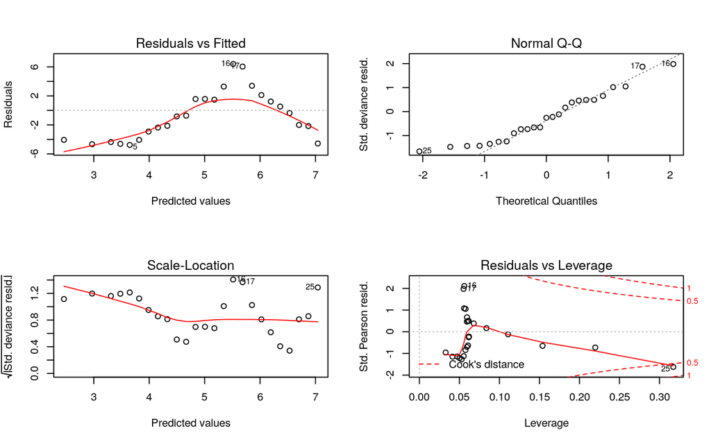

```r
poisson1quasi <- glm(`Cumulative cases` ~ `Elapsed time`, data=cases, family=quasipoisson)
par(mfrow=c(2,2))
plot(poisson1quasi)
```

```r
pred.poisq <- poisson1quasi$fitted.values
res.stq <- (data1$`Cumulative cases` - pred.poisq)/sqrt(summary(poisson1quasi)$dispersion*pred.poisq)
print(paste("Estimated overdispersion", sum(res.stq^2)/23))
```

```
## [1] "Estimated overdispersion 0.999988649853625"
```

```r
paste("AIC:", poisson1quasi$aic)
```

```
## [1] "AIC: NA"
```

```r
paste(c("Null deviance: ", "Residual deviance:"),
       round(c(poisson1quasi$null.deviance, deviance(poisson1quasi)), 2))
```

```
## [1] "Null deviance:  7859.81"   "Residual deviance: 280.62"
```

## Quasi Poisson with `Elapsed time` and `Age` as predictor

```r
#Let's apply a quasi poisson and see what happens
#poisson2quasi <- glm(`Cumulative cases` ~ `Elapsed time` + `Edad_19_30` + `Edad_31_45` + `Edad_46_60` + `Edad_60_75` + `Edad_76+`, data=data1, family=quasipoisson)
#par(mfrow=c(2,2))
#plot(poisson1quasi)
#pred.poisq2 <- poisson2quasi$fitted.values
#res.stq2 <- (data1$`Cumulative cases` - pred.poisq2)/sqrt(summary(poisson2quasi)$dispersion*pred.poisq2)
#print(paste("Estimated overdispersion", sum(res.stq2^2)/18))
#paste("AIC:", poisson2quasi$aic)
#paste(c("Null deviance: ", "Residual deviance:"),
  #     round(c(poisson2quasi$null.deviance, deviance(poisson2quasi)), 2))
```

## The Bayesian approach

## Poisson regression

As a first attempt, we fit a simple Poisson regression:

\[ ln(\lambda_i) = \alpha + \beta\cdot elapsed\_time_i \\ y_i \sim \mathcal{Poisson}(\lambda_i) \\ \alpha \sim \mathcal{N}(0,1) \\ \beta \sim \mathcal{N}(0.25,1) \]

with \(i = 1,\dots,134\), being \(134\) the number of rows of our dataset, and \(y_i\) represents the number of cases.

For what concerns the `stan` program, we used the function `poisson_log_rng` to describe the distribution of \(y_i\), namely the number of cases each day and the function `poisson_log_lpmf` to specify the likelihood.

## Posterior predictive check

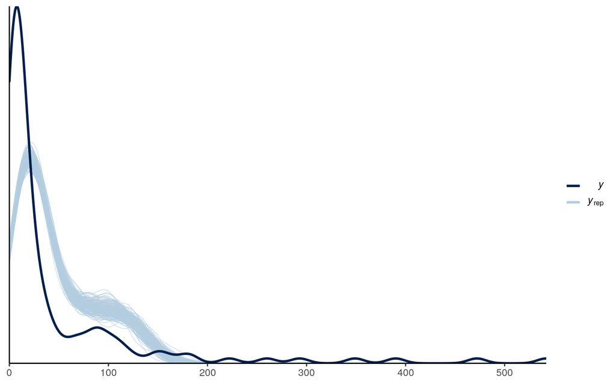

```r
y_rep<-as.matrix(fit1, pars="y_rep")
ppc_dens_overlay(y = model.data$cases, y_rep[1:200,])
```

The fit is not satisfactory, it is probably due to overdispersion, we can check the residuals to confirm this hypothesis.

## Residual check

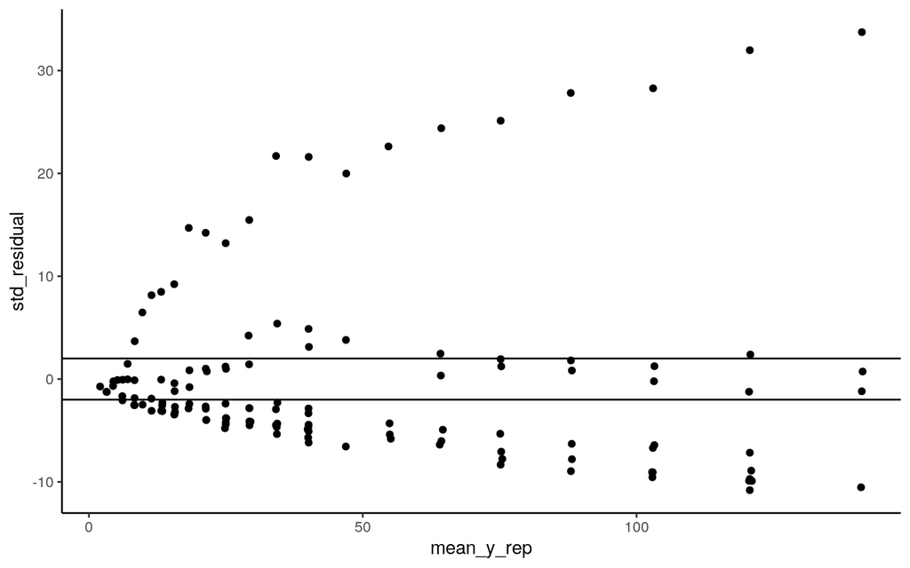

```r
#in this way we check the standardized residuals
mean_y_rep<-colMeans(y_rep)
std_residual<-(model.data$cases - mean_y_rep) / sqrt(mean_y_rep)
qplot(mean_y_rep, std_residual) + hline_at(2) + hline_at(-2)
```

The variance of the residuals increases as the predicted value increase. The standardized residuals should have mean 0 and standard deviation 1 (hence the lines at \(+2\) and \(-2\) indicates approximate \(95\%\) error bounds).

The plot of the standardized residuals indicates a large amount of overdispersion.

Classically the problem of having overdispersed data is solved using the negative binomial model instead of the Poisson’s one.

## Negative Binomial model

We try to improve the previous model using the Negative Binomial model:

\[ ln(\lambda_i) = \alpha + \beta\cdot elapsed\_time_i \\ y_i \sim \mathcal{Negative Binomial}(\lambda_i, \phi) \\ \alpha \sim \mathcal{N}(0,1) \\ \beta \sim \mathcal{N}(0.25,1) \]

Where the parameter \(\phi\) is called *precision* and it is such that:

\[ E[y_i] = \lambda_i \\ Var[y_i] = \lambda_i + \frac{\lambda_i^2}{\phi} \]

again \(i=1,\dots,134\). As \(\phi \rightarrow \infty\) the negative binomial approaches the Poisson distribution.

The `stan` function that we use here are `neg_binomial_2_log_rng` to specify the distribution of \(y_i\) and the function `neg_binomial_2_log_lpmf` for the likelihood.

## Posterior predictive check

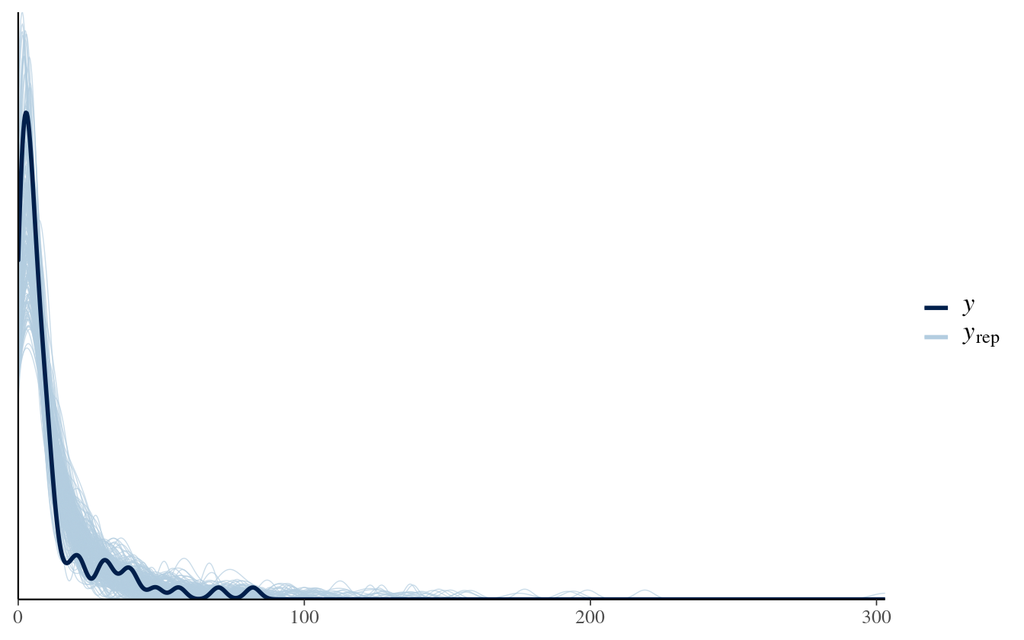

```r
samples_NB<-rstan::extract(fit2)
y_rep<-samples_NB$y_rep
ppc_dens_overlay(y = model.data$cases, y_rep[1:200,])
```

## Residual check

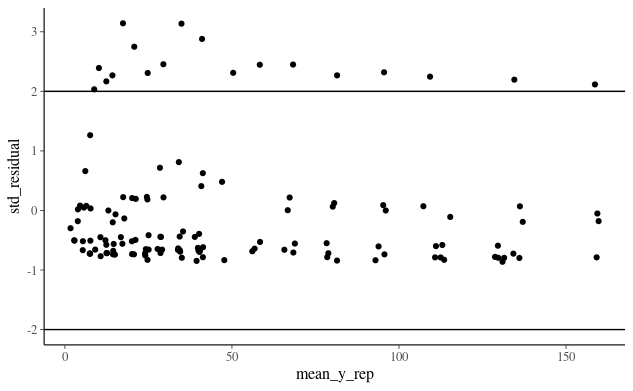

```r
mean_inv_phi<-mean(samples_NB$inv_phi)
mean_y_rep<-colMeans(y_rep)
std_residual<-(model.data$cases - mean_y_rep) / sqrt(mean_y_rep + mean_y_rep^2*mean_inv_phi)
qplot(mean_y_rep, std_residual) + hline_at(2) + hline_at(-2)
```

The situation is better now, but still we have too many residuals outside the \(95\%\) interval.

## Accuracy across departments

```r
ppc_stat_grouped(
  y = model.data$cases,
  yrep = y_rep,
  group = cases_dep$Department,
  stat = "mean",
  binwidth = 0.2
)
```

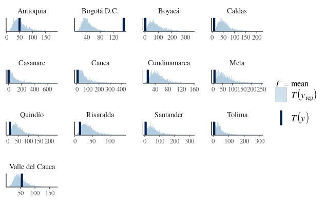

We should take into account the differences across departments.

## Multilevel Negative Binomial regression

We try to fit the following model, which also includes `Age` as covariat:

\[ ln(\lambda_i) = \alpha + \beta_{time}\cdot elapsed\_time_i + \beta_{age}\cdot age \\ y_i \sim \mathcal{Negative Binomial}(\lambda_i, \phi) \\ \alpha \sim \mathcal{N}(0,1) \\ \beta_{time} \sim \mathcal{N}(0.5,1) \\ \beta_{age} \sim \mathcal{N}(0,1) \]

## Posterior predictive check

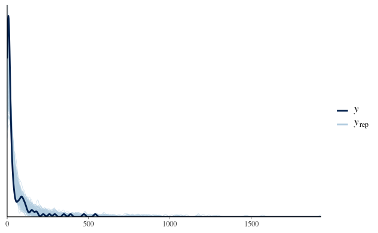

```r
samples_NB2<-rstan::extract(fit3)
y_rep<-samples_NB2$y_rep
ppc_dens_overlay(y = model.data2$cases, y_rep[1:200,])
```

## Residual check

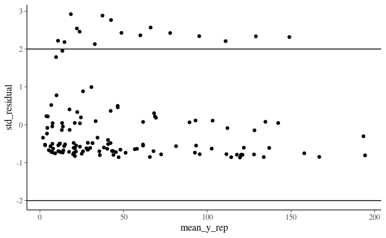

```r
mean_inv_phi<-mean(samples_NB2$inv_phi)
mean_y_rep<-colMeans(y_rep)
std_residual<-(model.data2$cases - mean_y_rep) / sqrt(mean_y_rep + mean_y_rep^2*mean_inv_phi)
qplot(mean_y_rep, std_residual) + hline_at(2) + hline_at(-2)
```

## Accuracy across departments

```r
ppc_stat_grouped(
  y = model.data2$cases,
  yrep = y_rep,
  group = cases_dep$Department,
  stat = "mean",
  binwidth = 0.2
)
```

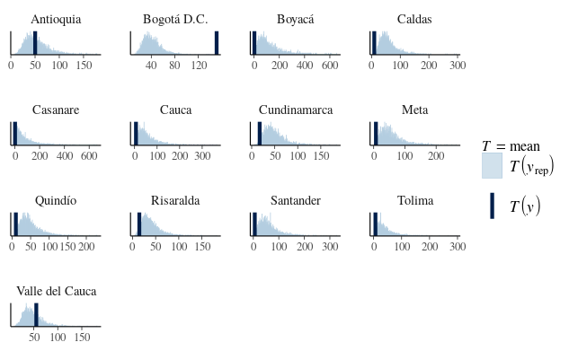

## Hierarchical model

In order to improve the fit, we fit a model with department-specific intercept term.

So the varying intercept model that we take into account is now:

\[ ln(\lambda_{i,d}) = \alpha_d + + \beta_{time}\cdot elapsed\_time_i + \beta_{age}\cdot age_i\\ \alpha_d \sim \mathcal{N}(\mu + \beta_{pop}\cdot pop_d + \beta_{sur}\cdot surface_d + \beta_{dens} \cdot density_d, \sigma_{\alpha})\\ y_i \sim \mathcal{Negative Binomial}(\lambda_{i,d}, \phi) \]

The priors used for the above model are the following:

\[ \beta_{time} \sim \mathcal{N}(0.5,1) \\ \beta_{age} \sim \mathcal{N}(0,1) \\ \psi \sim \mathcal{N}(0,1) \]

being \(\psi = [\beta_{pop}, \beta_{sur}, \beta_{dens}]\).

## New dataset

We added the following covariats into the dataset:

- `people`: millions of inhabitants for each region;
- `surface`: \(km^3\), extent of each region;
- `density`: \(\frac{people}{km^2}\), density of the population in each region.

## Posterior predictive check

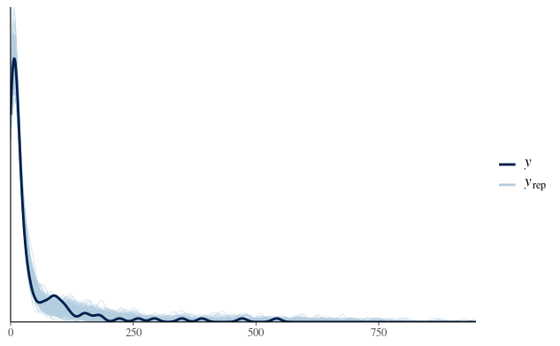

```r
samples_hier<-rstan::extract(fit4)
y_rep<-samples_hier$y_rep
ppc_dens_overlay(y = model.data.hier$cases, y_rep[1:200,])
```

## Residual check

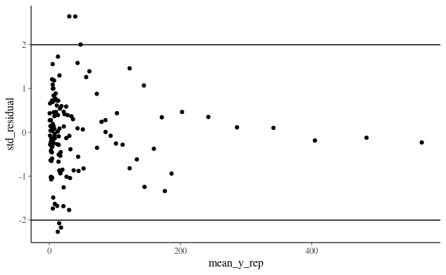

```r
mean_inv_phi<-mean(samples.hier$inv_phi)
mean_y_rep<-colMeans(y_rep)
std_residual<-(model.data.hier$cases - mean_y_rep) / sqrt(mean_y_rep + mean_y_rep^2*mean_inv_phi)
qplot(mean_y_rep, std_residual) + hline_at(2) + hline_at(-2)
```

Very few points are now outside the \(95\%\) confidence interval.

## Accuracy across departments

```r
ppc_stat_grouped(
  y = model.data.hier$cases,
  yrep = y_rep,
  group = cases_dep$Department,
  stat = "mean",
  binwidth = 0.2
)
```

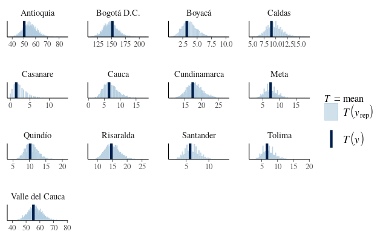

We can clearly see that the accuracy across the departments has significantly increased with respect to the previous models.